# Lab 2

Nathan Diekema

10/2/2021

### Setup

```r
library(tidyverse)

hiphop <- read_csv("data/hiphop.csv")
```

## **Summary**

```r
hiphop
```

```
## # A tibble: 10,752 x 38
##    word      subj  sex      age ethnic   city county  intl vocal classical  folk
##    <chr>     <chr> <chr>  <dbl> <chr>   <dbl>  <dbl> <dbl> <dbl>     <dbl> <dbl>
##  1 [to be] ~ p15   Female    20 white   33283 1.16e6     0     0         0     0
##  2 [to be] ~ p53   Female    17 white   34033 3.96e5     0     0         0     0
##  3 [to be] ~ p136  Male      41 white    8789 5.87e4     0     2         0     0
##  4 [to be] ~ p36   Female    18 white     712 1.49e5     0     0         0     1
##  5 [to be] ~ p118  Female    18 white   24280 1.54e5     0     3         3     0
##  6 [to be] ~ p106  Male      19 white  281262 5.06e5     0     0         0     0
##  7 [to be] ~ p70   Female    18 white  385542 1.16e6     0     0         0     2
##  8 [to be] ~ p107  Male      18 white     326 5.06e5     0     0         0     0
##  9 [to be] ~ p102  Male      19 asian    8471 1.01e5     0     0         0     0
## 10 [to be] ~ p83   Male      19 white   72878 1.16e6     0     1         0     0
## # ... with 10,742 more rows, and 27 more variables: rock <dbl>, country <dbl>,
## #   pop <dbl>, alternative <dbl>, hiphop <dbl>, unclassifiable <dbl>,
## #   countyBlack <dbl>, jayz <dbl>, barkley <dbl>, boondocks <dbl>,
## #   monique <dbl>, bieber <dbl>, asianMove <dbl>, blackMove <dbl>,
## #   hispanicMove <dbl>, nativeMove <dbl>, SAAMEMove <dbl>, whiteMove <dbl>,
## #   blackWeekly <dbl>, jayz1 <dbl>, boondocks1 <dbl>, familiarity <dbl>,
## #   trial <dbl>, fam1 <dbl>, popularityScore <dbl>, ...
```

**1. Provide a brief overview of the dataset**  
This dataset consists of data collected from 168 participants, measuring their familiarity with Africa-American English (AAE). AAE is a dialect of English spoken predominantly by African-Americans in the US and is associated with certain grammatical features such as the lack of the verb “to be” and other vocabulary items such as “A-town” or “shorty”. The dataset includes variables providing information on every participant demographics, music-taste, pop-culture knowledge, and more. The dataset as a whole consists of 10,752 rows with 38 variables each.

**2. Clean the dataset in whichever ways you see fit. This might mean adjusting variable type, for example from “character” to “factor”, or dealing with missing data.**

```r
hiphop_clean <-
  hiphop %>%
  drop_na(c(ethnic, sex, age)) %>%
  mutate_at(vars(ethnic, fam1), as.factor)


hiphop_clean
```

```
## # A tibble: 10,752 x 38
##    word      subj  sex      age ethnic   city county  intl vocal classical  folk
##    <chr>     <chr> <chr>  <dbl> <fct>   <dbl>  <dbl> <dbl> <dbl>     <dbl> <dbl>
##  1 [to be] ~ p15   Female    20 white   33283 1.16e6     0     0         0     0
##  2 [to be] ~ p53   Female    17 white   34033 3.96e5     0     0         0     0
##  3 [to be] ~ p136  Male      41 white    8789 5.87e4     0     2         0     0
##  4 [to be] ~ p36   Female    18 white     712 1.49e5     0     0         0     1
##  5 [to be] ~ p118  Female    18 white   24280 1.54e5     0     3         3     0
##  6 [to be] ~ p106  Male      19 white  281262 5.06e5     0     0         0     0
##  7 [to be] ~ p70   Female    18 white  385542 1.16e6     0     0         0     2
##  8 [to be] ~ p107  Male      18 white     326 5.06e5     0     0         0     0
##  9 [to be] ~ p102  Male      19 asian    8471 1.01e5     0     0         0     0
## 10 [to be] ~ p83   Male      19 white   72878 1.16e6     0     1         0     0
## # ... with 10,742 more rows, and 27 more variables: rock <dbl>, country <dbl>,
## #   pop <dbl>, alternative <dbl>, hiphop <dbl>, unclassifiable <dbl>,
## #   countyBlack <dbl>, jayz <dbl>, barkley <dbl>, boondocks <dbl>,
## #   monique <dbl>, bieber <dbl>, asianMove <dbl>, blackMove <dbl>,
## #   hispanicMove <dbl>, nativeMove <dbl>, SAAMEMove <dbl>, whiteMove <dbl>,
## #   blackWeekly <dbl>, jayz1 <dbl>, boondocks1 <dbl>, familiarity <dbl>,
## #   trial <dbl>, fam1 <fct>, popularityScore <dbl>, ...
```

**3. How many unique AAVE words were studied in this dataset?**

```r
length(unique(hiphop$word))
```

```
## [1] 64
```

There are **64** unique AAVE words in this dataset.

**4. Make a new variable that recategorizes ethnic into only two groups, “white” and “non-white”, to simplify your data.**

```r
hiphop_clean$bin_ethnic <- ifelse(hiphop_clean$ethnic == "white", "white", "non-white")
```

**5. What are the demographics of the people in this study? Investigate the variables sex, age, and ethnic and summarize your findings**

```r
## Number of distinct variables in each column
hiphop_clean %>%
  select(sex, age, ethnic) %>%
  summarize_all(c("n_distinct", "mean"))
```

```
## # A tibble: 1 x 6
##   sex_n_distinct age_n_distinct ethnic_n_distinct sex_mean age_mean ethnic_mean
##            <int>          <int>             <int>    <dbl>    <dbl>       <dbl>
## 1              2             21                 9       NA     20.0          NA
```

```r
## Averages of demographic variables in each column
hiphop_clean %>%
  select(age) %>%
  summarize_all(c("range"))
```

```
## # A tibble: 2 x 1
##     age
##   <dbl>
## 1    16
## 2    48
```

```r
## Distribution of ethnicity and age
temp <-
  hiphop_clean %>%
  filter(word=="A-town")


addmargins(table(temp$ethnic, temp$sex))
```

```
##
##            Female Male Sum
##   african       4    1   5
##   asian        14    5  19
##   biracial      1    0   1
##   black         1    0   1
##   hispanic      3    0   3
##   indian        2    0   2
##   native        1    0   1
##   unknown       0    1   1
##   white        91   44 135
##   Sum         117   51 168
```

The demographics variables included in this dataset include: sex, age, and ethnicity. The ages of participants ranged from 16 to 48 years old with an average age of 20. The dataset consists of primarily female participants making up nearly 70% of the 168 total participants. In terms of ethnicity, approximately 80% of the participants identified as being white, 11% were asian, 3% were african, and the rest were either biracial, indian, native-american, hispanic, or unknown. A summary of the distribution of ethnicity and gender is shown in the table above.

**6. Make at least two plots to display the demographic information of the subjects in this study. You do not need to discuss these plots, but make sure they are appropriate to the data types and have informative titles and axis labels.**

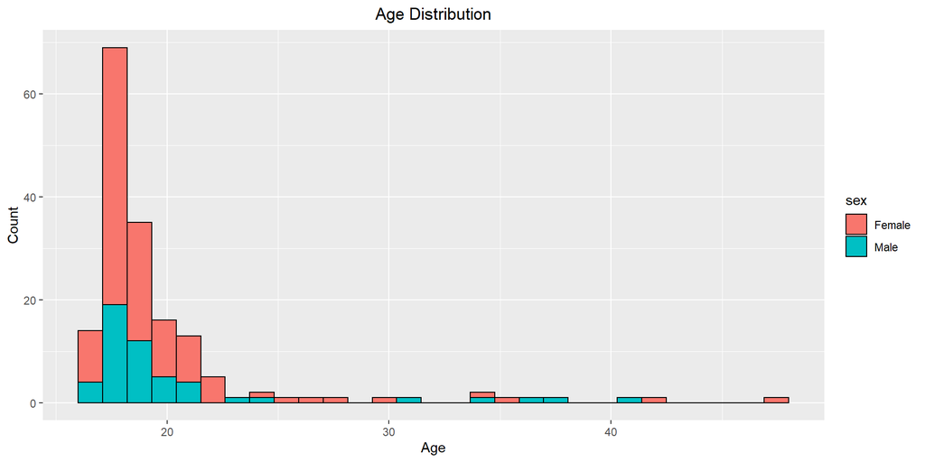

```r
## Plot comparing age distribution
hiphop_clean %>%
  select(age,sex,ethnic,word) %>%
  filter(word=="A-town") %>%
  ggplot(aes(x=age, fill=sex)) +
    geom_histogram(color="black") +
    labs(title="Age Distribution",
         y="Count") +
    scale_x_continuous(name="Age", breaks = seq(0, 70, 10)) +
    theme(plot.title = element_text(hjust = 0.5))
```

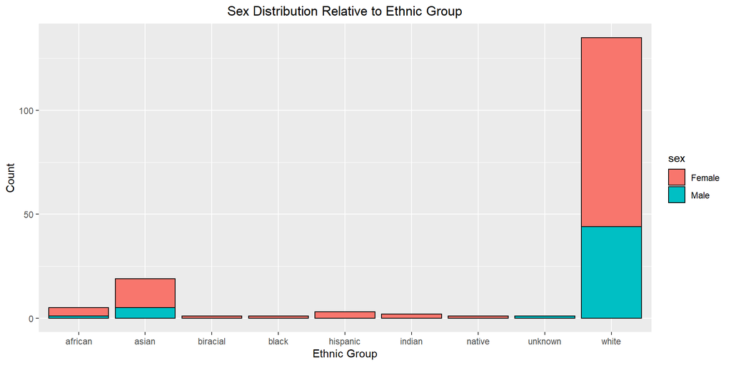

```r
## Plot comparing ethnicity distribution
hiphop_clean %>%
  select(age,sex,ethnic, word) %>%
  filter(word=="A-town") %>%
  ggplot(aes(x=ethnic, fill=sex)) +
    geom_bar(color="black") +
    labs(title="Sex Distribution Relative to Ethnic Group",
         y="Count",
         x="Ethnic Group") +
      theme(plot.title = element_text(hjust = 0.5))
```

## **Familiar Words**

**1. For each demographic group listed below, determine which word(s) in this study was the most and least familiar on average.**

- People below the age of 20
- Non-white women
- White men above the age of 30

```r
## People below the age of 20

compare <-
  hiphop_clean %>%
  select(word, age, familiarity) %>%
  filter(age < 20) %>%
  group_by(word) %>%
  summarize(
    avg_fam=mean(familiarity)
    )

slice_min(compare, avg_fam)
```

```
## # A tibble: 1 x 2
##   word             avg_fam
##   <chr>              <dbl>
## 1 catch the vapors    1.03
```

```r
slice_max(compare, avg_fam)
```

```
## # A tibble: 1 x 2
##   word         avg_fam
##   <chr>          <dbl>
## 1 off the hook    4.42
```

```r
## Non-white women

compare <-
  hiphop_clean %>%
  select(word, sex, bin_ethnic, familiarity) %>%
  filter(sex == "Female" & bin_ethnic == "non-white") %>%
  group_by(word) %>%
  summarize(
    avg_fam=mean(familiarity)
    )

slice_min(compare, avg_fam)
```

```
## # A tibble: 4 x 2
##   word              avg_fam
##   <chr>               <dbl>
## 1 break someone out       1
## 2 dukey rope              1
## 3 plex                    1
## 4 rollie                  1
```

```r
slice_max(compare, avg_fam)
```

```
## # A tibble: 1 x 2
##   word    avg_fam
##   <chr>     <dbl>
## 1 feel me    4.19
```

```r
## White men above the age of 30

compare <-
  hiphop_clean %>%
  select(word, age, sex, bin_ethnic, familiarity) %>%
  filter(sex == "Male" & bin_ethnic == "white" & age > 30) %>%
  group_by(word) %>%
  summarize(
    avg_fam=mean(familiarity)
    )

slice_min(compare, avg_fam)
```

```
## # A tibble: 25 x 2
##    word              avg_fam
##    <chr>               <dbl>
##  1 ay yo trip              1
##  2 beezy                   1
##  3 break someone out       1
##  4 catch the vapors        1
##  5 crossroads              1
##  6 crump                   1
##  7 dap                     1
##  8 dollar cab              1
##  9 domino                  1
## 10 duckets                 1
## # ... with 15 more rows
```

```r
slice_max(compare, avg_fam)
```

```
## # A tibble: 1 x 2
##   word  avg_fam
##   <chr>   <dbl>
## 1 5-0       4.2
```

- People below the age of 20
  - Most Familiar: “off the hook”
  - Least Familiar: “catch the vapors”
- Non-white women
  - Most Familiar: “feel me”
  - Least Familiar: “break someone out”, “dukey rope”, “plex”, “rollie”
- White men above the age of 30
  - Most Familiar: “5-0”
  - Least Familiar: “ay yo trip”, “beezy”, “break someone out”, “catch the vapors” “crossroads”, “crump”, etc. (look at the table above)

**2. For each demographic comparison below, determine which music genre most differentiates the groups. That is, which genre had much higher average (mean or median) score in one group than the other.**

- Male versus Female
- White versus Non-White
- Age below 21 versus age 21+

```r
## Male vs Female

genre_diff <-
  hiphop_clean %>%
  select(sex, intl, vocal, classical, folk, rock, country, pop, alternative, hiphop) %>%
  group_by(sex) %>%
  summarize_each(
    mean
  )
genre_diff %>%
  t() %>%
  data.frame() %>%
  slice(-c(1)) %>%
  setNames(c("female", "male")) %>%
  mutate_at(vars(female, male), as.numeric) %>%
  mutate(difference = abs(female - male)) %>%
  arrange(desc(difference))
```

```
##                female      male difference
## rock        1.9316240 3.0588240  1.1272000
## vocal       0.8803419 1.5686275  0.6882856
## country     0.7863248 0.3921569  0.3941679
## pop         1.2991450 1.0980390  0.2011060
## intl        0.4444444 0.2549020  0.1895424
## classical   0.7521368 0.9411765  0.1890397
## hiphop      1.6239320 1.5294120  0.0945200
## alternative 2.2136750 2.1568630  0.0568120
## folk        0.4017094 0.3921569  0.0095525
```

```r
## White versus Non-White

genre_diff <-
  hiphop_clean %>%
  select(bin_ethnic, intl, vocal, classical, folk, rock, country, pop, alternative, hiphop) %>%
  group_by(bin_ethnic) %>%
  summarize_each(
    mean
    )

genre_diff %>%
  t() %>%
  data.frame() %>%
  slice(-c(1)) %>%
  setNames(c("non-white", "white")) %>%
  mutate_at(vars(white, `non-white`), as.numeric) %>%
  mutate(difference = abs(white - `non-white`)) %>%
  arrange(desc(difference))
```

```
##             non-white      white difference
## intl        1.6666667 0.07407407  1.5925926
## rock        1.0606060 2.57037000  1.5097640
## alternative 1.2424240 2.42963000  1.1872060
## hiphop      2.1818180 1.45185200  0.7299660
## vocal       0.6666667 1.19259260  0.5259259
## country     0.2727273 0.76296300  0.4902357
## folk        0.1818182 0.45185190  0.2700337
## classical   0.8484848 0.80000000  0.0484848
## pop         1.2727270 1.22963000  0.0430970
```

```r
## Age below 21 versus age 21+

# Make a new column that is 1 if the participant is over 21yo and 0 if not
hiphop_clean$below_21 <- ifelse(hiphop_clean$age < 21, 1, 0)

genre_diff <-
  hiphop_clean %>%
  select(below_21, intl, vocal, classical, folk, rock, country, pop, alternative, hiphop) %>%
  group_by(below_21) %>%
  summarize_each(
    mean
    )

genre_diff %>%
  t() %>%
  data.frame() %>%
  slice(-c(1)) %>%
  setNames(c("above_21", "below_21")) %>%
  mutate_at(vars(above_21, below_21), as.numeric) %>%
  mutate(difference = abs(above_21 - below_21)) %>%
  arrange(desc(difference))
```

```
##              above_21  below_21 difference
## alternative 2.5000000 2.1194030 0.38059701
## intl        0.1176471 0.4552239 0.33757682
## hiphop      1.3529412 1.6567164 0.30377524
## vocal       0.9411765 1.1268657 0.18568920
## classical   0.8823529 0.7910448 0.09130817
## rock        2.3235294 2.2611940 0.06233538
## pop         1.2058824 1.2462687 0.04038630
## folk        0.4117647 0.3955224 0.01624232
## country     0.6764706 0.6641791 0.01229148
```

- When comparing males and females in this dataset, the most differentiating music genre is **Rock**
- The most differentiating music genre for whites versus non-whites is **International**
- The most differentiating music genre for people below 21 and 21+ is **Alternative**

Out of all of these comparisons, the groups with the largest differences in music taste are whites vs non-whites followed by males vs females.

## **Use The Data**

**A former Canadian child TV star named Aubrey Graham is interested in switching careers to become a rapper. Aubrey hires you to consult the hiphop dataset to help compose his new songs.**

**1. Aubrey hopes that his songs will be percieved as authentically hiphop. He hopes his lyrics will be recognizeable to those who describe themselves as hiphop fans, but less recognizeable to those who do not consider themselves fans. Suggest some words or phrases that Aubrey should try to use, and some words he should avoid.**

```r
## Find words that are recognizable by "fans" of hiphop
words1 <-
  hiphop_clean %>%
  select(word, familiarity, hiphop) %>%
  filter(hiphop > 3) %>%
  group_by(word) %>%
  summarize(
    avg_fam_fans=mean(familiarity)
  )

## Find words that are recognizable by "fans" of hiphop
words2 <-
  hiphop_clean %>%
  select(word, familiarity, hiphop) %>%
  filter(hiphop < 2) %>%
  group_by(word) %>%
  summarize(
    avg_fam_not_fans=mean(familiarity)
  )

## Combine the two tables
compare_words <- left_join(x=words1, y=words2, by="word")

## Add a column with the difference between familiarity
compare_words %>%
  mutate(difference = abs(avg_fam_fans - avg_fam_not_fans)) %>%
  arrange(desc(difference))
```

```
## # A tibble: 64 x 4
##    word         avg_fam_fans avg_fam_not_fans difference
##    <chr>               <dbl>            <dbl>      <dbl>
##  1 finna                3.59             1.87      1.72
##  2 what it do           3.81             2.55      1.26
##  3 twurk                2.78             1.61      1.17
##  4 make it rain         3.66             2.52      1.13
##  5 grip                 2.62             1.50      1.12
##  6 wile out             2.62             1.55      1.07
##  7 roll deep            2.56             1.53      1.03
##  8 What it is?          3.44             2.45      0.989
##  9 hella                4.31             3.39      0.920
## 10 stupid               2.06             1.19      0.876
## # ... with 54 more rows
```

**Suggestions**

Words to use:

- finna
- hella
- what it do
- make it rain
- what it is?
- 5-0

Words to avoid:

- humming
- heezy
- domino
- off the hook
- chitlins
- The Nation

**2. Although Aubrey wants to be authentic, he also hopes to sell records, of course. Two titles have been suggested for his first album: “Hotline Boo” or “Hella Bling”. Based on the dataset, which will appeal more to the higher population areas? Make at least one plot to support your answer.**

```r
compare_words <-
  hiphop_clean %>%
  select(word, county, familiarity, hiphop) %>%
  filter(county > 500000,
    word == c("hotline","boo", "hella", "bling")) %>%
  group_by(word) %>%
  summarize(
    avg_fam=mean(familiarity),
    avg_pop=mean(county)
  )

compare_words
```

```
## # A tibble: 2 x 3
##   word  avg_fam  avg_pop
##   <chr>   <dbl>    <dbl>
## 1 boo      3.33  868990.
## 2 hella    4.23 1054213.
```

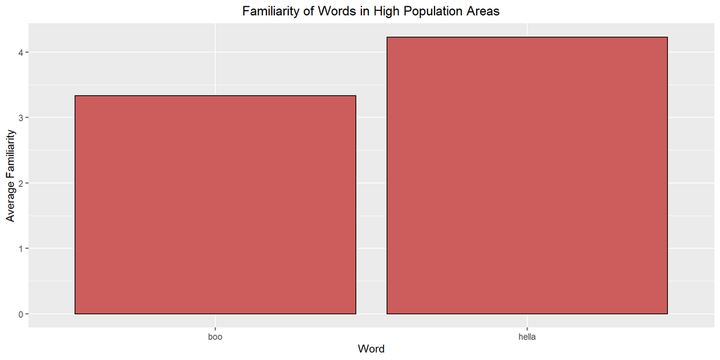

```r
compare_words %>%
  ggplot(aes(x=word, y=avg_fam)) +
  geom_bar(stat="identity",fill="indianred", color="black") +
  labs(title="Familiarity of Words in High Population Areas",
       y="Average Familiarity",
       x="Word") +
      theme(plot.title = element_text(hjust = 0.5))
```

Based on the average familiarity of the words “boo” and “hella” in high population areas, we can estimate that the album name “Hella Bling” will appeal more to people in higher population areas. That being said, there is not a huge difference between the average familiarities so it’s hard to make a confident conclusion from the data.

**3. Aubrey’s true life dream is to collaborate with his fellow Canadian musician Justin Bieber. Luckily, he knows that Bieber himself was one of the subjects in this study! You know that Bieber is a white male, aged 17-23 at the time of the study, from a relatively small town (10,000-60,000 people) in Ontario. Determine which subject is secretly Bieber, and justify your answer.**

```r
bieber <-
  hiphop_clean %>%
  distinct(subj, .keep_all = TRUE) %>%
  filter(city >= 10000 & city <= 60000,
        age >= 17 & age <= 23,
        ethnic == "white",
        sex == "Male",
        bieber >= 5)

bieber
```

```
## # A tibble: 1 x 40
##   word   subj  sex     age ethnic  city county  intl vocal classical  folk  rock
##   <chr>  <chr> <chr> <dbl> <fct>  <dbl>  <dbl> <dbl> <dbl>     <dbl> <dbl> <dbl>
## 1 [to b~ p17   Male     18 white  56377 331582     0     1         0     0     1
## # ... with 28 more variables: country <dbl>, pop <dbl>, alternative <dbl>,
## #   hiphop <dbl>, unclassifiable <dbl>, countyBlack <dbl>, jayz <dbl>,
## #   barkley <dbl>, boondocks <dbl>, monique <dbl>, bieber <dbl>,
## #   asianMove <dbl>, blackMove <dbl>, hispanicMove <dbl>, nativeMove <dbl>,
## #   SAAMEMove <dbl>, whiteMove <dbl>, blackWeekly <dbl>, jayz1 <dbl>,
## #   boondocks1 <dbl>, familiarity <dbl>, trial <dbl>, fam1 <fct>,
## #   popularityScore <dbl>, numPreferredArtists <dbl>, ...
```

Based on the information given about Bieber, my best guess is that subject p17 is secretly Bieber. This subject is an 18 year old white male from a small city. To differentiate who Bieber was from the few other subjects that met the same requirements, I used the bieber variable. Subject p17 was the only subject to name more than 4 Bieber songs so it’s a good guess that this is Justin Bieber.

## **Challenge**

```r
popular_words <-
  hiphop_clean %>%
  filter(city >= 50000,
        hiphop > 3) %>%
  group_by(word) %>%
  summarize(
    avg_fam=mean(familiarity)
  )

popular_words %>%
  arrange(desc(avg_fam))
```

```
## # A tibble: 64 x 2
##    word         avg_fam
##    <chr>          <dbl>
##  1 feel me         4.29
##  2 off the hook    4.29
##  3 hella           4.18
##  4 boo             3.71
##  5 what it do      3.71
##  6 finna           3.53
##  7 ballin'         3.41
##  8 make it rain    3.35
##  9 player hater    3.35
## 10 ashy            3.29
## # ... with 54 more rows
```

**Hella Bling Track List**

1. Finna get loose
2. What it do (feat. Nicki Minaj)
3. Make it rain
4. Boo thang
5. You feel me?
6. Make it rain
7. Ballin’
8. A-town girl
9. You know what it is
10. Hella ass in this bish
11. Player hater

For the track names on this album I used some of the words with the highest average familiarity for people who live in decently large cities and who likely consider themselves fans of hiphip. I picked these filters because I figured the people who are most likely going to listen to this album in the first place are those who are fans of hiphop and also the majority of the population lives in cities. I incorporated many of the most familiar words in the track names to appeal to people in this population.